# ESM 244 Assignment 3: Task 3

Meghan Fletcher

2/19/2021

#### **Overview:** In this report, I performed a text and sentiment analysis on the book *Harry Potter and the Sorcerer’s Stone* by J.K. Rowling. All copy rights belong to author J.K Rowling. The PDF was sourced from: http://www.getfreestories.weebly.com/uploads/7/9/0/2/79020522/harry_potter_and_the_sorcerers_-_j.k._rowling.pdf

```r
# Read in Harry Potter and the Sorcer's Stone
hp_text <- pdf_text("harry_potter_and_the_sorcerers_JKrowling.pdf")
```

## Part 1: Text Analysis

```r
# Make the text tidy
hp_tidy <- data.frame(hp_text) %>%
  mutate(text_full = str_split(hp_text, pattern ="\\n")) %>%
  unnest(text_full) %>%
  mutate(text_full = str_trim(text_full))
```

```r
# Make it even tidier!
hp_df <- hp_tidy %>%
  slice(-(1:44)) %>%
    mutate(chapter = case_when(
    str_detect(text_full, pattern = "CHAPTER") ~ text_full,
    TRUE ~ NA_character_
  )) %>%
  fill(chapter) %>%
  separate(col = chapter, into = c("ch", "no"), sep = " ") %>%
  mutate(chapter = case_when(
    no == "ONE" ~ 1,
    no == "TWO" ~ 2,
    no == "THREE" ~ 3,
    no == "FOUR" ~ 4,
    no == "FIVE" ~ 5,
    no == "SIX" ~ 6,
    no == "SEVEN"~ 7,
    no == "EIGHT" ~ 8,
    no == "NINE" ~ 9,
    no == "TEN" ~ 10,
    no == "ELEVEN" ~ 11,
    no == "TWELVE" ~ 12,
    no == "THIRTEEN" ~ 13,
    no == "FOURTEEN" ~ 14,
    no == "FIFTEEN" ~ 15,
    no == "SIXTEEN" ~ 16,
    no == "SEVENTEEN" ~ 17
  )) %>%
  mutate(chapter = as.numeric(chapter))
```

```r
# Get tokens of the text
hp_tokens <- hp_df %>%
  unnest_tokens(word, text_full) %>%
  dplyr::select(-hp_text)

# Get word counts
hp_wordcount <- hp_tokens %>%
  count(chapter, word)
```

```r
# Remove all stop words
hp_nonstop_words <- hp_tokens %>%
  anti_join(stop_words)

# Get counts again
hp_nonstop_counts <- hp_nonstop_words %>%
  count(chapter, word)
```

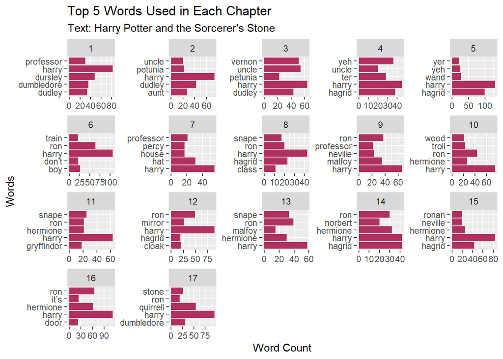

```r
# Find the top 5 words from each chapter
hp_top5_words <- hp_nonstop_counts %>%
  group_by(chapter) %>%
  arrange(-n) %>%
  slice(1:5)

ggplot(data = hp_top5_words, aes(x = word, y = n)) +
  geom_col(fill = "maroon") +
  facet_wrap(~chapter, scales = "free") +
  coord_flip() +
  labs(x = "Words", y = "Word Count", title = "Top 5 Words Used in Each Chapter", subtitle = "Text: Harry Potter and the Sorcerer's Stone")
```

**Figure 1:** The top 5 words used in each chapter of *Harry Potter and the Sorcerer’s Stone* by J.K. Rowling can reveal a lot about what occurs in each chapter. For instance, in chapter four the words ‘hagrid’ and ‘yeh’ are used a lot. This is because in that chapter Harry, the main character, meets Hagrid for the first time and Hagrid talks with an accent that often includes the phrase ‘yeh’.

```r
# Make a word cloud for ch. 7 (ie. the chapter where Harry get's sorted into Gryffindor)
ch7_top100 <- hp_nonstop_counts %>%
  filter(chapter == "7") %>%
  arrange(-n) %>%
  slice(1:100)
```

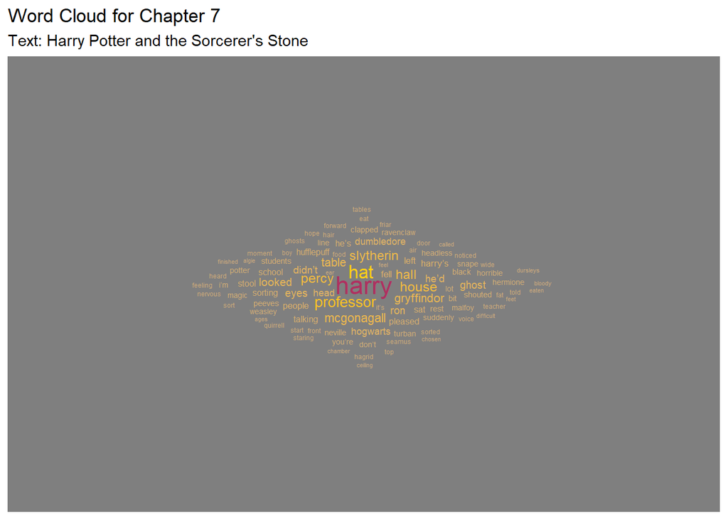

```r
ch7_cloud <- ggplot(data = ch7_top100, aes(label = word)) +
  geom_text_wordcloud(aes(color = n, size = n), shape = "diamond") +
  scale_size_area(max_size = 6) +
  scale_color_gradientn(colors = c("burlywood3", "goldenrod1","gold","maroon")) +
  theme_dark() +
  labs(title = "Word Cloud for Chapter 7", subtitle = "Text: Harry Potter and the Sorcerer's Stone")

ch7_cloud
```

**Figure 2:** A word cloud of chapter 7 can reveal a lot about that chapter specifically. In this chapter, the word “hat” and “percy” are used a lot. This makes sense becasue in this chapter, Harry meets Percy and is also sorted into Gryffindor by the sorting hat. The other house names are also referenced many times in this chapter.

## Part 2: Sentiment Analyis

```r
# Bring hp test and afinn lexicon together
hp_afinn <- hp_nonstop_words %>%
  inner_join(get_sentiments("afinn"))

# Find counts based on snetiment rnaking from afinn lexicon
hp_afinn_counts <- hp_afinn %>%
  count(chapter, value)

# Find the mean afinn score by chapter
hp_afinn_means <- hp_afinn %>%
  group_by(chapter) %>%
  summarize(mean_afinn = mean(value))
```

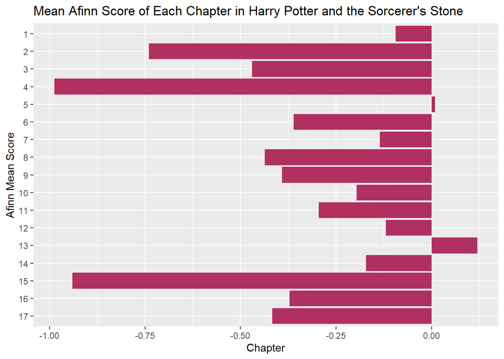

```r
# Plot the hp afinn ranking (mean of each chapter)
ggplot(data = hp_afinn_means,
       aes(x = fct_rev(as.factor(chapter)),
           y = mean_afinn)) +
  geom_col(fill="maroon") +
  coord_flip() +
  labs(x = "Afinn Mean Score", y = "Chapter", title = "Mean Afinn Score of Each Chapter in Harry Potter and the Sorcerer's Stone")
```